# Longevity and Happiness

Wentao Li, Hongyan Zheng

7/5/2021

## Blog

### The Questions and the Reason

The decade of The Tens marked a period of great international migration and travel. Whether it was in the cabin of international flights, the deck of a cruise ship, or the backseat of a minivan, travelling, adventuring and migrating defined the decade as people seek a better life for their family and children. According to the United Nations, by the end of the decade, the number of international migrant reached 272 million, with Europe and North America receiving the majority. The pursuit of material success often mirrored a pursuit of a happy, long-lasting life. This was reflected in the recent World Happiness Reports, in which Nordic countries often topped the charts in their happiness rank, the Life Ladder Rank. Therefore we conceded ourselves to the following main questions that has inquired millenniums of philosophy and religion: “Is there a possible way to maximize human life expectancy? Is happiness the key?”

In the below study, we hope to examine the various socioeconomic variables that would affect both happiness and life expectancy, how geography impacts happiness and life expectancy, and whether having a high life expectancy had any relations to having a happy life, and vice versa. To analyze these possible relationships, we have asked ourselves the following questions: “Does a change in life expectancy reflect a similar change in happiness with the most impactful socioeconomic variable in common, vise versa?”, “Are these socioeconomic variables provided by the World Happiness Report significant to life expectancy?”, “Which variable affects life expectancy and happiness the most?”, “How does life expectation and happiness change over time for each continent?”.

### Finding the data

To answer these relationship and questions, we have imported, cleaned and analyzed three data sets, “The World Happiness Report” powered by data from Gallup World Poll, “Global Life Expectancy” collected from ourworldindata.org, and a data set containing all countries and their respective continents. Both “The World Happiness Report” and “Global Life Expectancy” data sets were filtered such that only statistics from 2008 to 2019 is observed, as it not only contains the full decade from 2010 to 2019, but also 2 years prior to observe the statistics prior to the start of the decade.

### Each Continent’s Life Expectancy and Happiness over Time

To discover the relationship between geography (continents) and life expectancy and subsequently happiness, we mainly utilized the built-in functions of ggplot. We separately plotted “Life Expectancy” and “Happiness” against “Year”, to show the change in life expectancy from 2008 to 2019, and separated the different values for different continents.

Here’s how life expectancy and happiness for each continent has changed over the last decade:

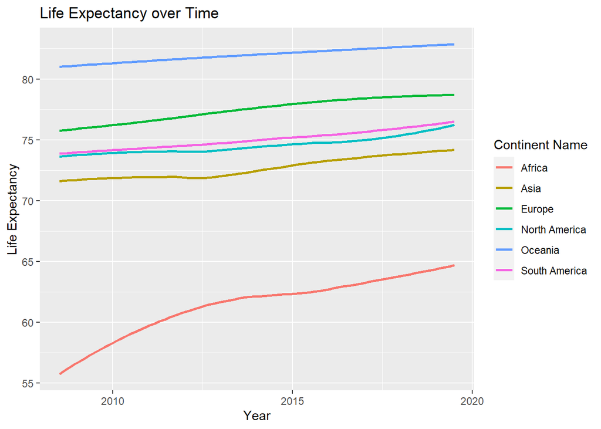

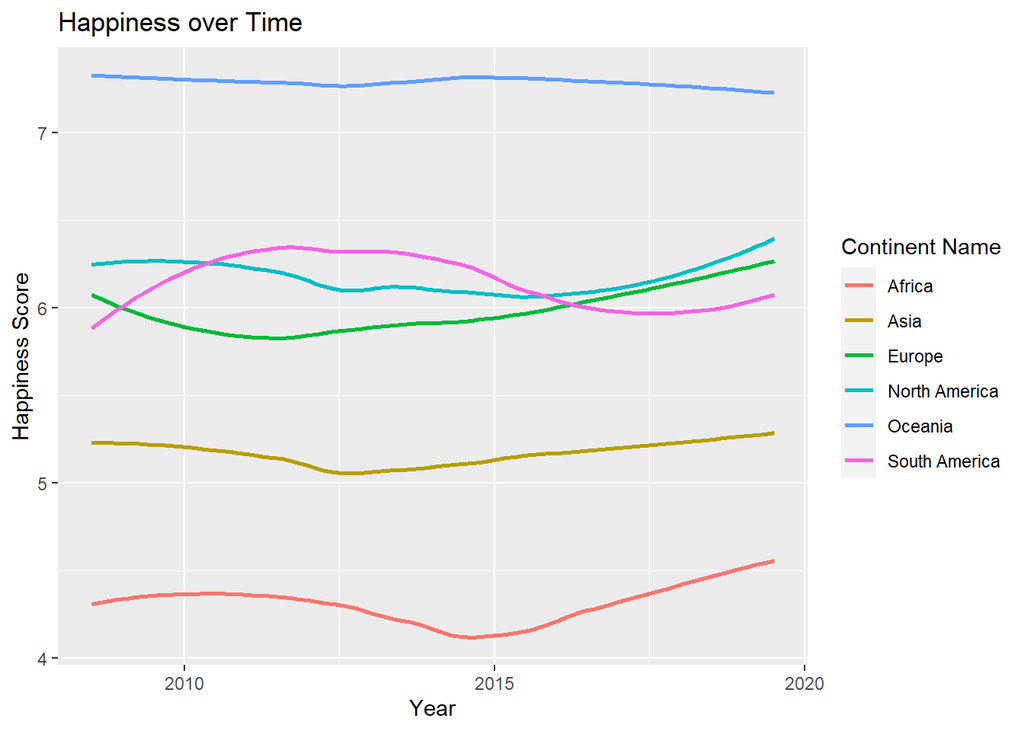

As we can see, countries in Oceania has managed to not only be more happy but also a longer life expectancy, while countries in Africa has experienced drastically lower life expectancy and happiness, and other countries from other continents have remained somewhere in between. Moreover, we can observe that in general, all continents are seemingly improving their life expectancy, yet happiness for many continents has had drastic change In the last decade. There are a few other interesting observations in this graph, such as: South America’s drastic rise in happiness surpassing North America and Europe from 2010 to 2015 and then its subsequent fall back below the other two continents, and Africa’s strong rise in Life Expectancy which is not reflected in happiness until after 2015..

### Finding the Most Impactful Socioeconomic Variable for Happiness and Life Expectancy

To further analyze the reason behind these changes, we look to discover the relationship between socio-economic variables and life expectancy, we utilized a linear regression model to analyze our data due to the large amount of numeric values. We were able to discover which values were significant. And through this process, we discovered that in relation to life expectancy, all other variables except “Happiness Score” and “Perception of Corruption” are relatively significant. Therefore we can conclude from this data that relatively to other variables, how a person view corruption and their happiness score has a relatively less significant impact on their life expectancy.

In fact, we can explore this further and discover which variable has the most effect on both life expectancy and worldwide happiness. Further utilizing linear models, creating weights and tidy tools to acknowledge the sparse data collected from Africa, we were able to discover that for happiness and life expectancy, the most significant variable in common was “Positive Affect”. This result meant that the average of previous-day affect measures for happiness, laughter, and enjoyment is the most impactful weighted variable in relationship to both Happpiness and Life Expectancy.

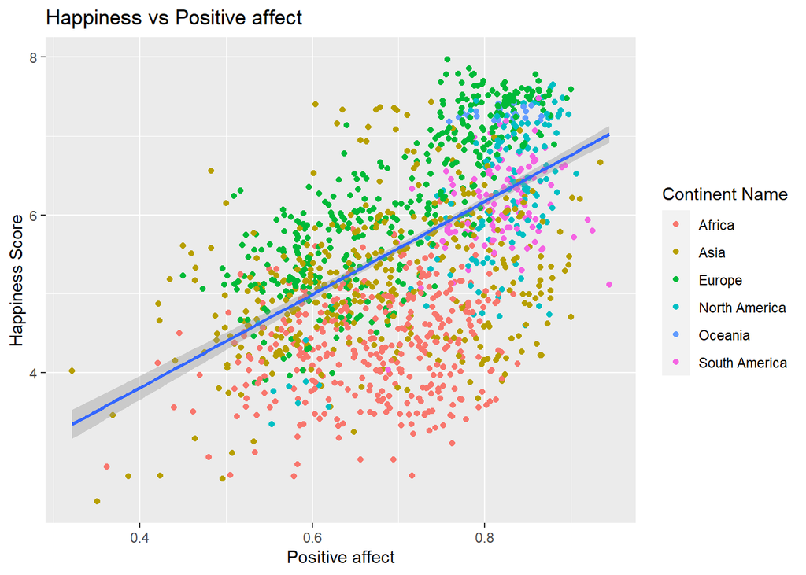

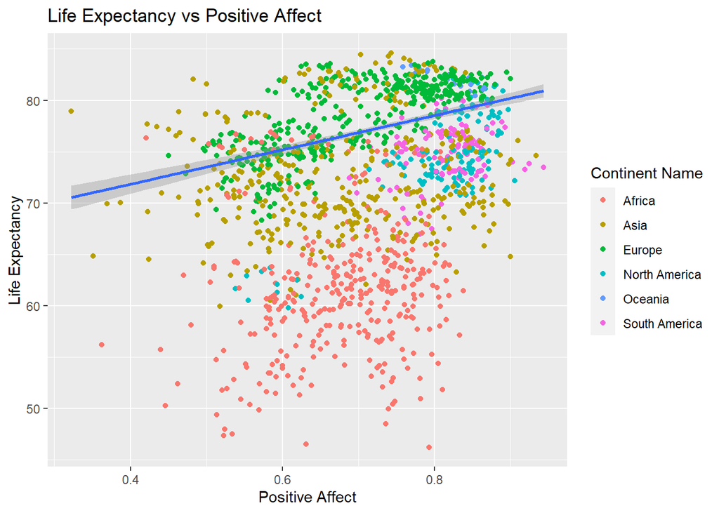

*As we can see from the above plot, one of the life Expectancy or happiness score with Positive affect will return a positive relationship in general.

Positive Affect has a positive relationship with both life expectancy and happiness. And more importantly, both “Happiness” and “Life Expectancy” follows the previous established relationship with “Geography”.*

### Does Changing Life Expectancy Reflect a Similar Change in Happiness?

This allows us to advance to the final question to our discussion. What is the relationship between happiness and life expectancy with the most impactful variable in common? Are happy people more likely to live longer? And more importantly, if they are related, how does the change in one variable affect the change in another?

To answer this question, we utilized linear regression models, creating weights and tidy tools to observe and validify the relationship between Life Expectancy and Happiness if we take the most significant common variable, Positive Affect, out of our consideration. We are able to conclude that 1 unit increase in Happiness Score would increase 5.344248 years in Life Expectancy, and 1 unit increase in Positive affect would decrease 11.428228 years in Life Expectancy, and conversely, 1 unit increase in Life Expectancy would increase 0.09346093 in Happiness Score, and 1 unit increase in Positive affect would increase 3.74537396 in Happiness Score. Additionally, a change in Life Expectancy doesn’t reflect a similar change in Happiness Score if we include the most significant common variable, Positive affect, because it brings negative effect to Life Expectancy but positive effect to Happiness Score on the other hand.

Based on the observation, there’s a positive relationship between Life Expectancy and Happiness Score, and between Happiness score and Life Expectancy if we take the most impactful common variable, Positive affect, out of our consideration.

Here is how Life Expectancy is related to Happiness, and conversely:

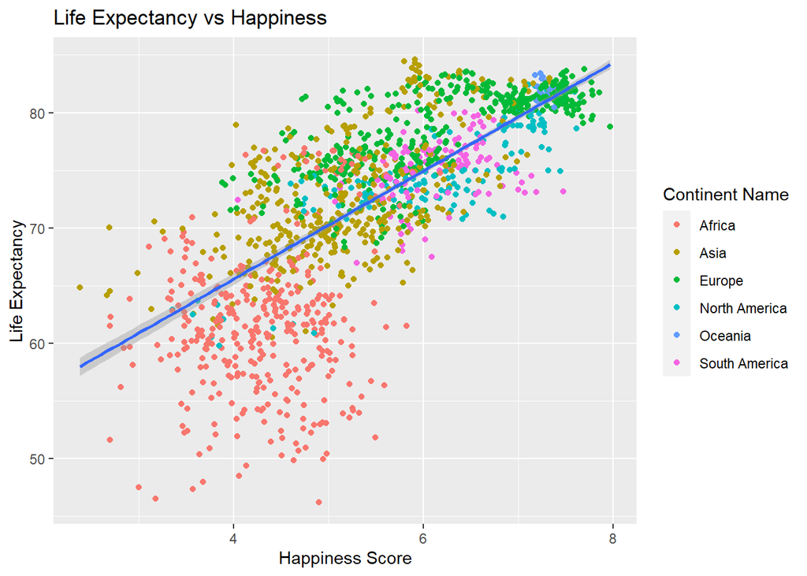

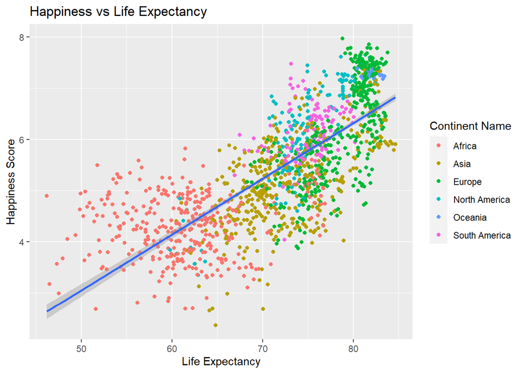

### Conclusion

In conclusion, although we expected it, we were fascinated to observe that each continent had distinct patterns in Happiness Score and Life Expectancy from 2008 to 2019, especially the rise and fall for South America’s Happiness Score. Subsequently, finding that the socioeconomic variable “Positive Affect”, or how one perceives their happiness, was the most impactful variable in common which was positively related to both Life Expectancy and Happiness Score. Furthermore, we learned that Life Expectancy and Happiness Score have a positive and linear relationship, such that increasing one may lead to the increase of another, even though there are other variables that have a more significant impact on both Happiness and Life Expectancy. Therefore, although there exists a positive relationship between Happiness and Life Expectancy, neither are the sole key to both.

## Technical Analysis

### Overview and Motivation:

Throughout history, humans often struggle to find the solution to extend their mortality or even immortality. From inventing elixirs to offering sacrifices, yet we have seldom heard of those who have achieved this goal, yet various cultures across the globe have attempted it. Advancing into the 21st century, when many viral and bacterial diseases are preventable and infant mortality rate has dropped drastically, we pursue the question again, “what is the secret to longevity? Is happiness the key?”. Moreover, Nordic countries have consistently claimed the top seats in the World Happiness Report while maintaining a unique social welfare program. In this study, we hope to explore the reason, the variable with the highest impact, on Happiness Score.

In the following report, we have analyzed three important data sets, “The World Happiness Report” powered by data from Gallup World Poll, “Global Life Expectancy” collected from ourworldindata.org, and a data set containing various countries and their respective continents via datahub.io, to discover the relationships between Global Life Expectancy and Global Happiness Score (represented by the Life Ladder Rank) and its various subsequent economic and social factors. We have discovered these relationships through combining data sets and cleaning the data, selecting specific response variables, finding significant explanatory variables, utilizing graphs to show the relationship between response and all explanatory variables, checking model assumptions and model building and showing the influence of significant explanatory variables vs. the response variable.

### Initial Questions:

The study attempts to find the relationship between Life Expectancy and Happiness Score through exploring the following questions: “Are all Social and Economic variables such as GDP, Social Support, Freedom of Choice, Healthy Life Expectancy at birth, Generosity, Perceptions of corruption, Positive affect, and Negative affect related to Life Expectancy?”, “What is the relationship between Geography (continent) and Life Expectancy?”, “What is the relationship between Geography (continent) and Happiness Score?”, “Do happy people live longer? If so, which variable affects both Life Expectancy and Happiness Score the most?”, and finally “Does a change in Life Expectancy reflect a similar change in Happiness Score with the most significant variable in common??”.

In its initial stages, the study also hoped to explore the relationship between COVID-19 cases across the world and each country’s socioeconomic variables as well as global happiness. However, due to COVID-19 being a very recent event, and its long-lasting socioeconomic impacts, it was decided after consideration to exclude these questions and the data sets all together, and instead focusing on further exploring the relationship between Life Expectancy and Happiness Score. This allowed us to explore the last two questions, and further examine how both the socioeconomic variables and happiness impact Life Expectancy.

### Data:

We used the following packages for our analysis:

```r
library(readr)
library(tidyverse)
library(ggrepel)
library(tidyr)
library(tidymodels)
```

```r
lifeExpectancy_world <- read_csv("lifeExpectancy_world.csv")
world_happiness_report <- read_csv("world-happiness-report.csv")
continent_country_tag <- read.csv("country-and-continent-codes-list-csv_csv.csv")
```

Here, we imported 3 csv files and stored them with respective names. Two of them are sourced from kaggle, and the other is datahub.io

```r
continent_country_tag[is.na(continent_country_tag)]="NA"

continent_country_tag <- continent_country_tag %>% rename("Code" = Three_Letter_Country_Code)

data <- lifeExpectancy_world %>%
  rename("Country name" = Entity) %>%
  pivot_longer(3:72, names_to = "year", values_to = "Expectancy") %>%
  mutate(year = as.numeric(year)) %>%
  filter(year >= 2008) %>%
  left_join(world_happiness_report) %>%
  left_join(continent_country_tag, by = "Code") %>%
  na.omit() %>%
  mutate(year = as.Date(as.character(year), format = "%Y"))

glimpse(data)
```

```
## Rows: 1,499
## Columns: 18
## $ `Country name`                     <chr> "Afghanistan", "Afghanistan", "Afgh~
## $ Code                               <chr> "AFG", "AFG", "AFG", "AFG", "AFG", ~
## $ year                               <date> 2008-07-06, 2009-07-06, 2010-07-06~
## $ Expectancy                         <dbl> 59.930, 60.484, 61.028, 61.553, 62.~
## $ `Life Ladder`                      <dbl> 3.724, 4.402, 4.758, 3.832, 3.783, ~
## $ `Log GDP per capita`               <dbl> 7.370, 7.540, 7.647, 7.620, 7.705, ~
## $ `Social support`                   <dbl> 0.451, 0.552, 0.539, 0.521, 0.521, ~
## $ `Healthy life expectancy at birth` <dbl> 50.80, 51.20, 51.60, 51.92, 52.24, ~
## $ `Freedom to make life choices`     <dbl> 0.718, 0.679, 0.600, 0.496, 0.531, ~
## $ Generosity                         <dbl> 0.168, 0.190, 0.121, 0.162, 0.236, ~
## $ `Perceptions of corruption`        <dbl> 0.882, 0.850, 0.707, 0.731, 0.776, ~
## $ `Positive affect`                  <dbl> 0.518, 0.584, 0.618, 0.611, 0.710, ~
## $ `Negative affect`                  <dbl> 0.258, 0.237, 0.275, 0.267, 0.268, ~
## $ Continent_Name                     <chr> "Asia", "Asia", "Asia", "Asia", "As~
## $ Continent_Code                     <chr> "AS", "AS", "AS", "AS", "AS", "AS",~
## $ Country_Name                       <chr> "Afghanistan, Islamic Republic of",~
## $ Two_Letter_Country_Code            <chr> "AF", "AF", "AF", "AF", "AF", "AF",~
## $ Country_Number                     <chr> "4", "4", "4", "4", "4", "4", "4", ~
```

During the data cleaning, we changed the name and type of variables and used `left_join` and `na.omit()` function to combine all three data sets without any missing value. One important thing here is that the abbreviation of North America is NA, which should be defined as character instead of the missing value. Furthermore, we changed the type of the variable “year” from `double` to `date` in order to better serve ggplot functions and make our visualizations more reasonable.

### Exploratory Data Analysis:

#### Question 1:

*Are all Happiness Score variables such as GDP, Social Support, Freedom of Choice, Healthy Life Expectancy at birth, Generosity, Perceptions of corruption, Positive affect, and Negative affect significantly related to Life Expectancy?*

Initial Results:

```r
fit_all <- lm(Expectancy ~ `Log GDP per capita` + `Social support` +
            `Freedom to make life choices` + `Healthy life expectancy at birth` +
            `Generosity` + `Perceptions of corruption` +
            `Positive affect` + `Negative affect` + `Life Ladder`, data = data)
tidy(fit_all)
```

```
## # A tibble: 10 x 5
##    term                               estimate std.error statistic  p.value
##    <chr>                                 <dbl>     <dbl>     <dbl>    <dbl>
##  1 (Intercept)                          3.50      0.556      6.30  3.84e-10
##  2 `Log GDP per capita`                 0.716     0.0786     9.11  2.48e-19
##  3 `Social support`                    -1.96      0.507     -3.87  1.12e- 4
##  4 `Freedom to make life choices`      -0.784     0.373     -2.10  3.57e- 2
##  5 `Healthy life expectancy at birth`   1.01      0.0105    95.6   0
##  6 Generosity                           1.97      0.260      7.56  6.88e-14
##  7 `Perceptions of corruption`          0.252     0.251      1.01  3.14e- 1
##  8 `Positive affect`                   -1.66      0.499     -3.33  9.05e- 4
##  9 `Negative affect`                    2.03      0.515      3.94  8.43e- 5
## 10 `Life Ladder`                        0.0604    0.0682     0.886 3.76e- 1
```

First, we fitted a linear regression model with `lm()` function named as fit_all and print out the summary table with `tidy()` function because all variables in our data are numeric.

```r
tidy(fit_all) %>% filter(p.value > 0.05)
```

```
## # A tibble: 2 x 5
##   term                        estimate std.error statistic p.value
##   <chr>                          <dbl>     <dbl>     <dbl>   <dbl>
## 1 `Perceptions of corruption`   0.252     0.251      1.01    0.314
## 2 `Life Ladder`                 0.0604    0.0682     0.886   0.376
```

```r
fit_significant <- lm(Expectancy ~ `Log GDP per capita` + `Social support` +
                        `Freedom to make life choices` +
                        `Healthy life expectancy at birth` + `Generosity` +
                        `Positive affect` + `Negative affect`, data = data)
tidy(fit_significant)
```

```
## # A tibble: 8 x 5
##   term                               estimate std.error statistic  p.value
##   <chr>                                 <dbl>     <dbl>     <dbl>    <dbl>
## 1 (Intercept)                           3.57     0.446       8.02 2.17e-15
## 2 `Log GDP per capita`                  0.729    0.0733      9.96 1.19e-22
## 3 `Social support`                     -1.74     0.475      -3.67 2.47e- 4
## 4 `Freedom to make life choices`       -0.874    0.349      -2.50 1.24e- 2
## 5 `Healthy life expectancy at birth`    1.01     0.0104     97.5  0
## 6 Generosity                            1.95     0.253       7.70 2.38e-14
## 7 `Positive affect`                    -1.49     0.475      -3.14 1.74e- 3
## 8 `Negative affect`                     2.15     0.498       4.32 1.67e- 5
```

```r
anova(fit_all, fit_significant)
```

```
## Analysis of Variance Table
##
## Model 1: Expectancy ~ `Log GDP per capita` + `Social support` + `Freedom to make life choices` +
##     `Healthy life expectancy at birth` + Generosity + `Perceptions of corruption` +
##     `Positive affect` + `Negative affect` + `Life Ladder`
## Model 2: Expectancy ~ `Log GDP per capita` + `Social support` + `Freedom to make life choices` +
##     `Healthy life expectancy at birth` + Generosity + `Positive affect` +
##     `Negative affect`
##   Res.Df    RSS Df Sum of Sq      F Pr(>F)
## 1   1489 3075.9
## 2   1491 3079.1 -2   -3.1582 0.7644 0.4658
```

Secondly, we took out all the variables with p-value greater than 5% from the model and named it as fit_significant. Since the p-value of the Anova test is greater than 5%; therefore, the smaller model is a adequate fit of the larger one, and we choose the second model which contains less variables. The p-values of all the variables are less than 5% in the second model support our decision as well. A significant variable means that it brings in true impact to the response variable.

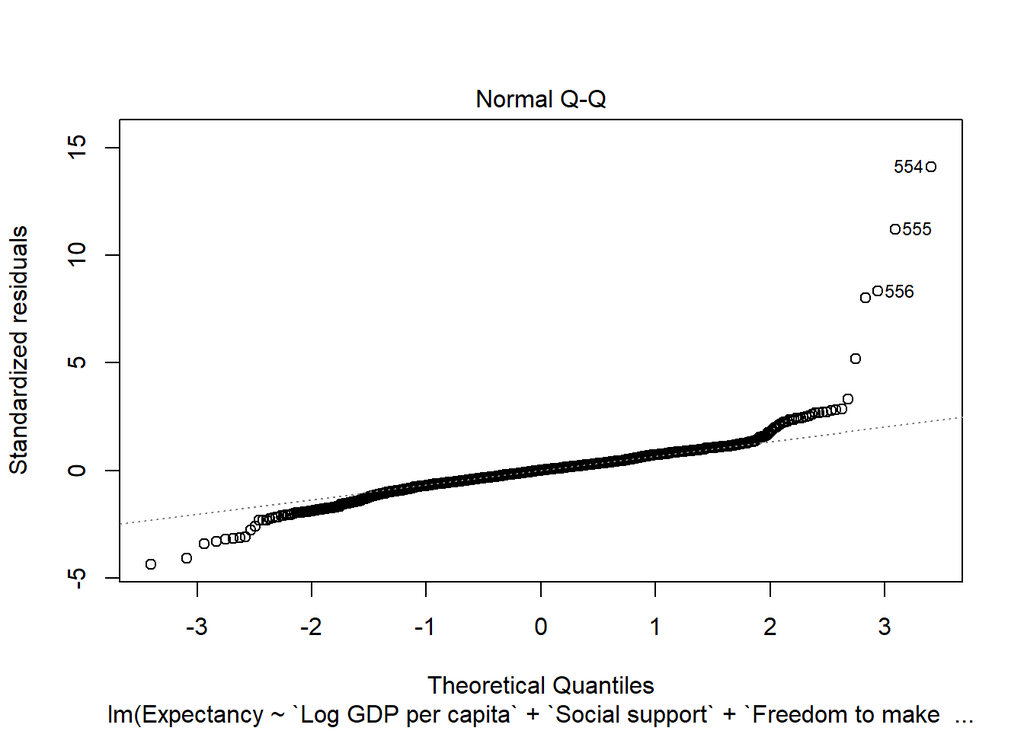

```r
plot(fit_significant, which = 2)
```

#### Question 2

Question: *What is the relationship between continents and Life Expectancy?*

Initial Results:

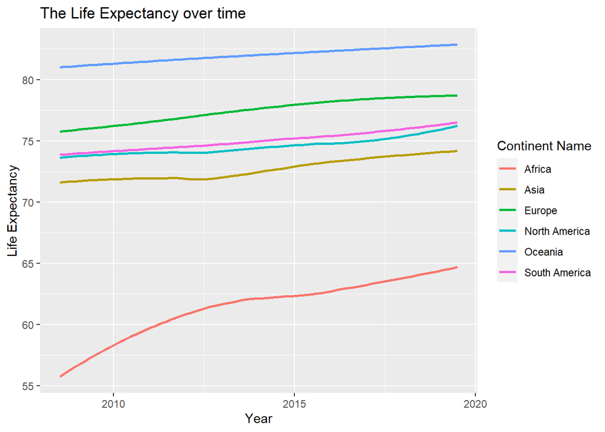

```r
data %>%
  select(Expectancy, Continent_Name, `year`) %>%
  group_by(Continent_Name) %>%
  ggplot(aes(year, Expectancy ,color = Continent_Name)) +
  geom_smooth(se = F) +
  ggtitle("The Life Expectancy over time") +
  labs(color = "Continent Name") +
  xlab("Year") +
  ylab("Life Expectancy")
```

First, we selected the variables that we interested in, and then grouped by the continents’ name. Secondly, we demonstrated the relationship with `ggplot()` function. Since we are interested in Life Expectancy, which is a continuous variable, and continents, which is a categorical variable, we also included a continuous variable, year, in order to make a reasonable plot. Based on the observation, there is definitely a relationship as different continents have drastically different life expectancy rates. Oceania has the highest life expectancy, followed by Europe, South America, North America, Asia and then subsequently Africa over time. We can also see that life expectancy for all continents have increased over time.

#### Question 3

Question: *what is the relationship between continents and Happiness Score?*

Initial Results:

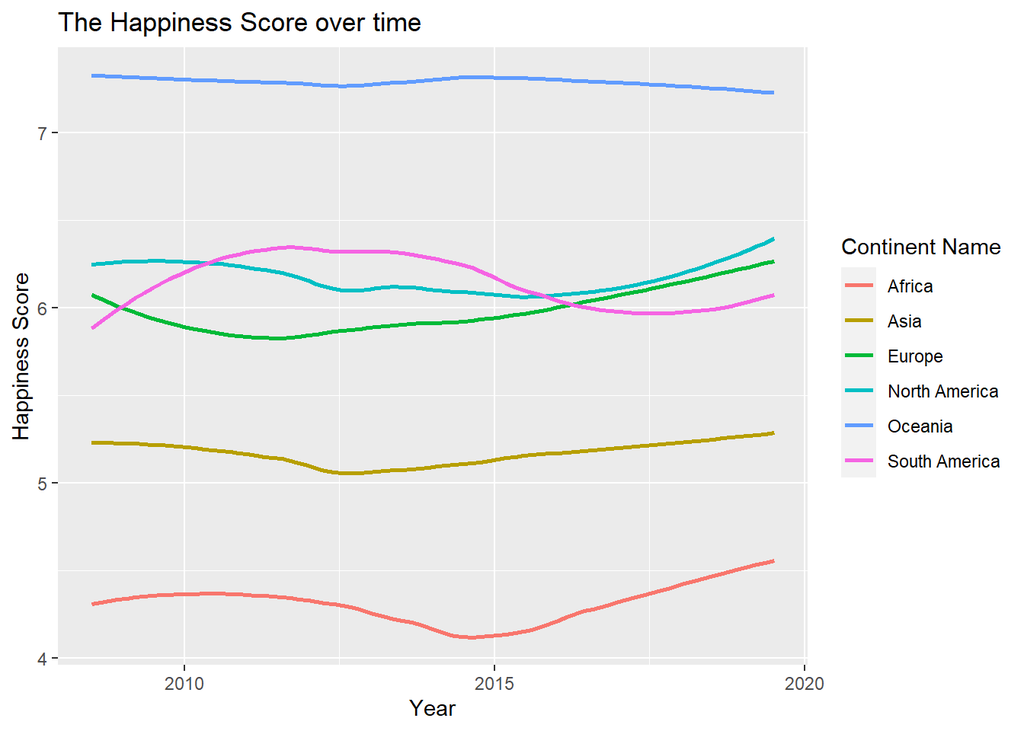

```r
data %>%
  select(year, `Life Ladder`, Continent_Name) %>%
  group_by(`Continent_Name`) %>%
  ggplot(aes(year, `Life Ladder` ,color = Continent_Name)) +
  geom_smooth(se = F) +
  ggtitle("The Happiness Score over time") +
  labs(color = "Continent Name") +
  xlab("Year") +
  ylab("Happiness Score")
```

First, we selected the variables that we interested in, and then grouped by the continents’ name. Secondly, we demonstrated the relationship with `ggplot()` function. Since we are interested in Life Ladder Happiness, which is a continuous variable, and continents, which is a categorical variable, we also included a continuous variable, year, in order to make a reasonable plot. Based on the observation, there is definitely a relationship as different continents have drastically different Life Ladder Happiness Ranking. Somewhat similar to life expectancy, Oceania has the highest life expectancy. However, from around 2010 to 2015, South America maintained a higher Happiness, and North America remained a higher Happiness than Europe. This could be due to some drastic events which needs further investigation.

#### Question 4

Question: *Do happy people live longer? If so which variable affects both Life Expectancy and Happiness Score the most?*

Initial Results:

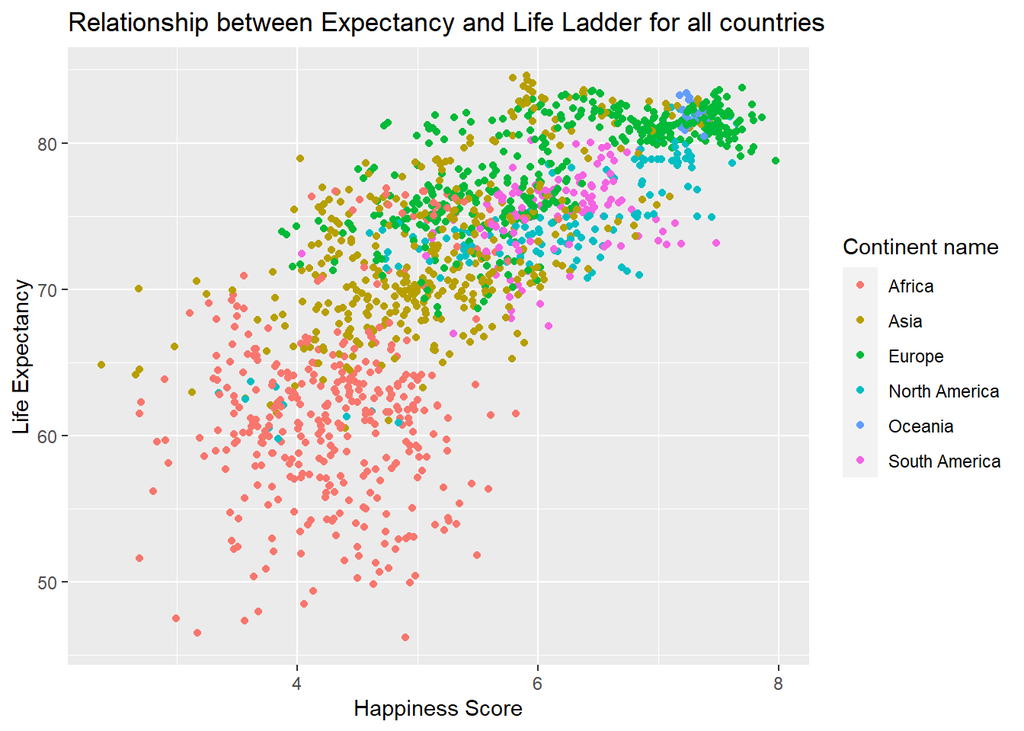

```r
data %>%
  select(Expectancy, `Life Ladder`, Continent_Name) %>%
  ggplot(aes(`Life Ladder`, Expectancy)) +
  geom_point(aes(color = Continent_Name)) +
  ggtitle("Relationship between Expectancy and Life Ladder for all countries") +
  xlab("Happiness Score") +
  ylab("Life Expectancy") +
  labs(color = "Continent name")
```

Here, we plot Life Expectancy against Happiness Score; based on the observation, there are positive linear relationships between Happiness Score and Life Expectancy among all the continents. Furtheremore, the points indicating African counties are spreading out sparsely; therefore, the variance is higher than the other categories in the Continent name, so we decided to add weights in the later linear regression models to make better analysis.

```r
mod_expc_o <- lm(Expectancy~`Log GDP per capita` + `Social support` +
                 `Freedom to make life choices` +`Life Ladder` +
                 `Healthy life expectancy at birth` + `Generosity` +
                 `Perceptions of corruption` + `Positive affect` +
                 `Negative affect`, data = data)

weights_expc <- 1 / lm(abs(mod_expc_o$residuals) ~ mod_expc_o$fitted.values)$fitted.values^2

mod_expc_w <- lm(Expectancy~`Log GDP per capita` + `Social support` +
                 `Freedom to make life choices` +`Life Ladder` +
                 `Healthy life expectancy at birth` + `Generosity` +
                 `Perceptions of corruption` + `Positive affect` +
                 `Negative affect`, data = data, weights = weights_expc)

(summary_exp<- tidy(mod_expc_w)) %>%
  slice(2:11) %>%
  arrange(desc(abs(estimate))) %>%
  select(1,2)
```

```
## # A tibble: 9 x 2
##   term                               estimate
##   <chr>                                 <dbl>
## 1 `Negative affect`                     2.42
## 2 `Positive affect`                    -2.30
## 3 `Perceptions of corruption`           1.12
## 4 Generosity                            1.04
## 5 `Healthy life expectancy at birth`    0.962
## 6 `Log GDP per capita`                  0.508
## 7 `Freedom to make life choices`        0.452
## 8 `Life Ladder`                         0.300
## 9 `Social support`                      0.204
```

Here, we built a linear regression models with Life Expectancy as the response variable. Then, we calculated the weights for each data point in order to re-build a linear regression with weighted least square. With tidy() function, we get summary table; subsequently, we arranged the order based on the absolute value for estimated coefficients. According to the results, the model suggests that `Negative affect`, `Positive affect`, `Perceptions of corruption` are the most impactful variables for Life Expectancy.

```r
mod_happy_o <- lm(`Life Ladder` ~ `Expectancy` + `Log GDP per capita` +
               `Social support` + `Freedom to make life choices` +
               `Healthy life expectancy at birth` + `Generosity` +
               `Perceptions of corruption` + `Positive affect` +
               `Negative affect`, data = data)

weights_happy <- 1 / lm(abs(mod_happy_o$residuals) ~ mod_happy_o$fitted.values)$fitted.values^2

mod_happy_w <- lm(`Life Ladder` ~ `Expectancy` + `Log GDP per capita` +
               `Social support` + `Freedom to make life choices` +
               `Healthy life expectancy at birth` + `Generosity` +
               `Perceptions of corruption` + `Positive affect` +
               `Negative affect`, data = data, weights = weights_happy)

(summary_ll <- tidy(mod_happy_w)) %>%
  slice(2:11) %>%
  arrange(desc(abs(estimate))) %>%
  select(1,2)
```

```
## # A tibble: 9 x 2
##   term                               estimate
##   <chr>                                 <dbl>
## 1 `Social support`                     2.29
## 2 `Positive affect`                    2.24
## 3 `Perceptions of corruption`         -0.715
## 4 Generosity                           0.374
## 5 `Log GDP per capita`                 0.348
## 6 `Freedom to make life choices`       0.314
## 7 `Negative affect`                    0.270
## 8 `Healthy life expectancy at birth`   0.0156
## 9 Expectancy                           0.0153
```

After the same process as the previous model, the model, mod_happy_w, suggests that `Social support`, `Positive affect`, `Perceptions of corruption` are the most impactful variables for Happiness Score. Thus, `Positive affect` is the most impactful variable in common for both responses.

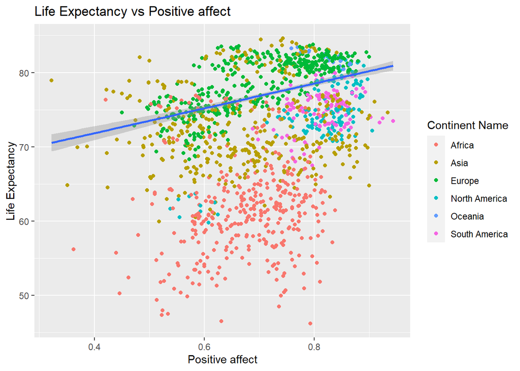

```r
#Life Expectancy vs Positive affect
data %>%
  select(`Positive affect`, Expectancy, Continent_Name) %>%
  ggplot(aes(x = `Positive affect`, y = Expectancy)) +
  geom_point(aes(color = Continent_Name)) +
  geom_smooth(method = "lm", aes(weight = weights_expc)) +
  ggtitle("Life Expectancy vs Positive affect") +
  ylab("Life Expectancy") +
  labs(color = "Continent Name")
```

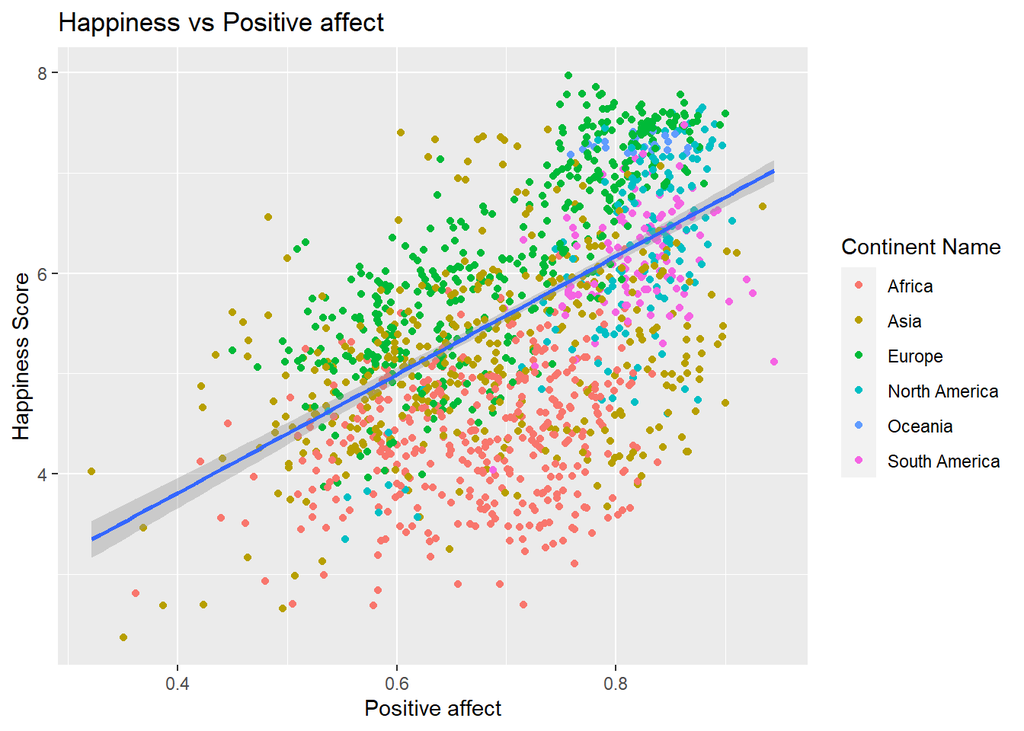

```r
#Happiness Score vs Positive affect
data %>%
  select(`Positive affect`, `Life Ladder`, Continent_Name) %>%
  ggplot(aes(x = `Positive affect`, y = `Life Ladder`)) +
  geom_point(aes(color = Continent_Name)) +
  geom_smooth(method = "lm", aes(weight = weights_happy)) +
  ggtitle("Happiness vs Positive affect") +
  ylab("Happiness Score") +
  labs(color = "Continent Name")
```

Hence, we used ggplot to illustrate the relationships of Positive affect against Life Expectancy and Happiness Score with weights. In general, Positive affect and Life Expectancy brings positive impact to Happiness Score; meanwhile, Positive affect brings negative impact while Happiness Score brings positive impact to Life Expectancy even though the trends are both positive.

#### Question 5

Question: *Does a change in Life Expectancy reflect a similar change in Happiness Score with the most impactful variable in common from Question 4?*

Initial Results:

```r
fit1 <- lm(Expectancy ~ `Life Ladder` + `Positive affect`, data = data)
weights_1 <- 1 / lm(abs(fit1$residuals) ~ fit1$fitted.values)$fitted.values^2
fit1_w <- lm(Expectancy ~ `Life Ladder` + `Positive affect`, data = data, weights = weights_1)
tidy(fit1_w)
```

```
## # A tibble: 3 x 5
##   term              estimate std.error statistic   p.value
##   <chr>                <dbl>     <dbl>     <dbl>     <dbl>
## 1 (Intercept)          51.2      0.802     63.8  0
## 2 `Life Ladder`         5.34     0.125     42.9  5.61e-263
## 3 `Positive affect`   -11.4      1.32      -8.63 1.54e- 17
```

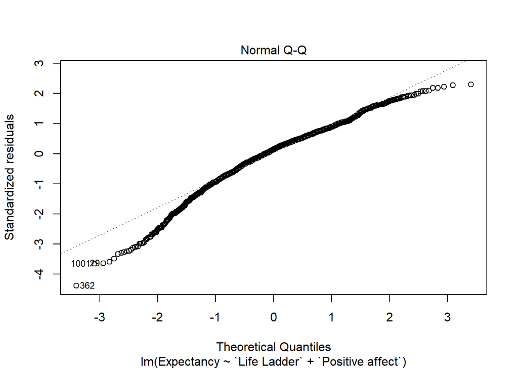

```r
plot(fit1_w, which = 2)
```

```r
fit2 <- lm(`Life Ladder` ~ Expectancy + `Positive affect`, data = data)
weights_2 <- 1 / lm(abs(fit2$residuals) ~ fit2$fitted.values)$fitted.values^2
fit2_w <- lm(`Life Ladder` ~ Expectancy + `Positive affect`, data = data, weights = weights_2)
tidy(fit2_w)
```

```
## # A tibble: 3 x 5
##   term              estimate std.error statistic   p.value
##   <chr>                <dbl>     <dbl>     <dbl>     <dbl>
## 1 (Intercept)        -3.94     0.175       -22.5 1.12e- 96
## 2 Expectancy          0.0935   0.00231      40.5 1.05e-242
## 3 `Positive affect`   3.75     0.160        23.4 1.80e-103
```

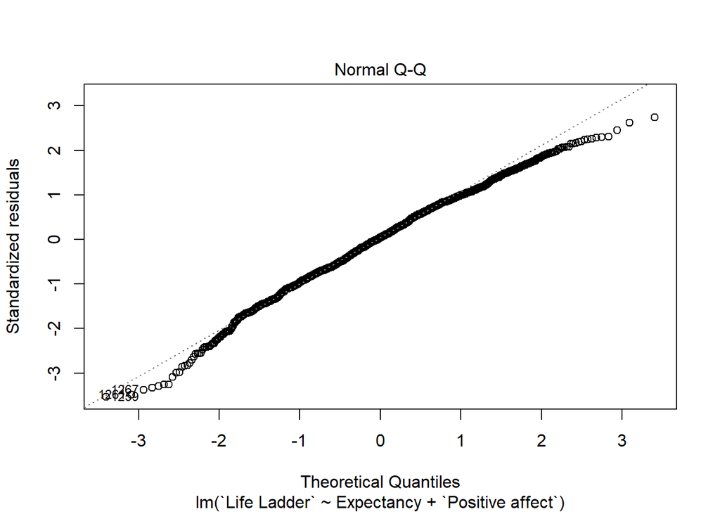

```r
plot(fit2_w, which = 2)
```

Here, we built two multiple linear regression models with Life Expectancy and Happiness Score as the response variable respectively and the other with the most significant variable, Positive affect, as our exploratory variables. Then, we check the model assumption with QQ plot, and it shows that the normality assumption is valid since the majority of residuals are along with the diagonal dash line. Both models have p-values less than 5% for Happiness Score and Life Expectancy, meaning these two variables are significant in both models. Looking at the estimate variable, both maintain a positive relationship. To interpret the relationship in the first model, we say 1 unit increase in Happiness Score would increase 5.344248 years in Life Expectancy, and 1 unit increase in Positive affect would decrease 11.428228 years in Life Expectancy. Similarly, for the second model, 1 unit increase in Life Expectancy would increase 0.09346093 in Happiness Score, and 1 unit increase in Positive affect would increase 3.74537396 in Happiness Score. Thus, we say a change in Life Expectancy doesn’t reflect a similar change in Happiness Score if we include the most significant common variable, Positive affect, because it brings negative effect to Life Expectancy but positive effect to Happiness Score on the other hand.

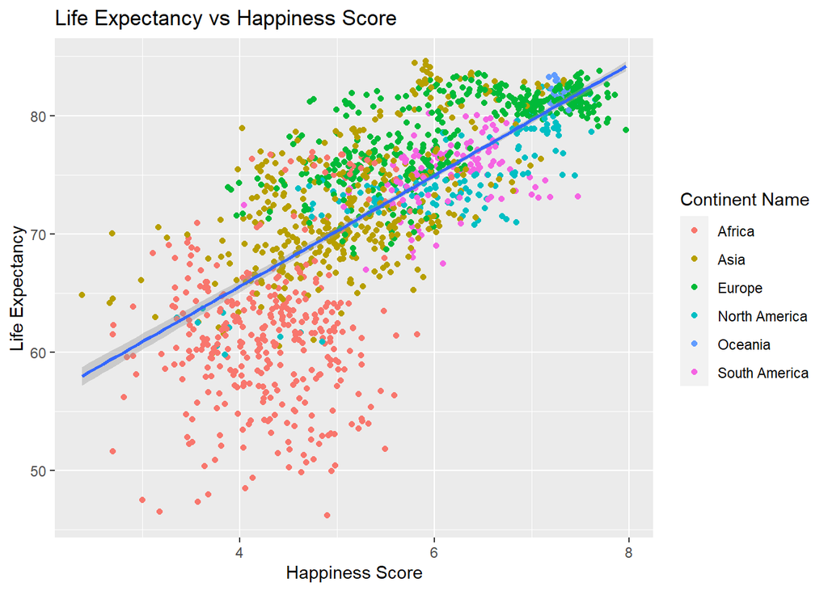

```r
data %>% select(`Life Ladder`, Expectancy, Continent_Name) %>%
  ggplot(aes(x = `Life Ladder`, y = Expectancy)) +
  geom_point(aes(color = Continent_Name)) +
  geom_smooth(method = "lm", aes(weight = weights_1)) +
  ggtitle("Life Expectancy vs Happiness Score") +
  xlab("Happiness Score") +
  ylab("Life Expectancy") +
  labs(color = "Continent Name")
```

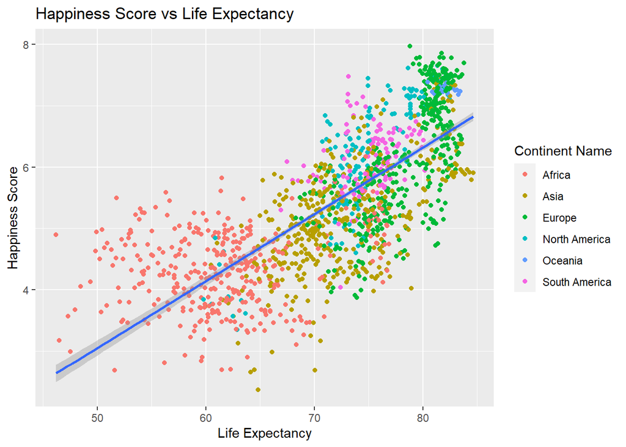

```r
data %>% select(`Life Ladder`, Expectancy, Continent_Name) %>%
  ggplot(aes(y = `Life Ladder`, x = Expectancy)) +
  geom_point(aes(color = Continent_Name)) +
  geom_smooth(method = "lm", aes(weight = weights_2)) +
  ggtitle("Happiness Score vs Life Expectancy") +
  ylab("Happiness Score") +
  xlab("Life Expectancy") +
  labs(color = "Continent Name")
```

Here, we demonstrated the plots of Life Expectancy against Happiness Score and Happiness Score against Life Expectancy. Created similarly to the plot of Life Expectancy against Happiness Score in the beginning of Question 4, we instead drew a weighted linear line to show the relationships. Based on the observation, there’s a positive relationship between Life Expectancy and Happiness Score if we take the most impactful common variable, Positive affect, out of our consideration.

### Final Analysis

In conclusion, we learn that the Life Expectancy and Happiness Score have positive linear relationships; therefore, an unit increase in one could lead to an unit increase in the other even though there are some more significant variables out there. For instance, Positive affect is the most impactful variable for both response variables commonly; in another word, an unit increase in Positive affect would lead to an impactful change in either Life Expectancy or Happiness Score. Unfortunately, it brings negative and positive impact to Life Expectancy and Happiness Score respectively; therefore, it’s not the variable we would like to maximize even though it’s the most impactful one. The questions were answered through creating and observing plots and linear regression models based on the given data sets. Results showed that through finding and observing the p-values of the linear models and creating Q-Q plots for checking the model assumption justify that the various types of linear regression are the reasonable method to reach our answers.

### Related Work

*https://pubmed.ncbi.nlm.nih.gov/31451635/*

This study was inspired by “Optimism is associated with exceptional longevity in 2 epidemiologic cohorts of men and women”, a study conducted by numerous researchers such as Lewina O Lee, Peter James, Emily S. Zevon, etc. This research tested whether higher optimism was associated with longer life span and greater likelihood of exceptional longevity. The researchers analyzed data from two large population studies: the Nurses’ Health Study of 70,000 women, and the Veterans Affairs Normative Aging Study of 1,400 men. It also analyzed Happiness through the Life Orientation Test from the Nurses’ Health Study and the Optimism-Pessimism Scale from the Normative Aging study. The researchers found that for both men and women, higher levels of optimism were associated with a longer life span. This study inspired us as the results had shown that optimism did have a relationship with longevity. Therefore, we hoped to expand the study from optimism to general Happiness and the focus from only the United States to a more global perspective. After reading the study, we hoped to explore whether Happiness Score, in our study represented by the Life Ladder rank, is related to life expectancy.